# Chi-square test for association

2024-11-07

## Source materials

- Music and Wine as well Pet ownership examples taken from an old introductory Stat class at Purdue.
- The shopping example is taken from the [tutorials by William B. King:](https://ww2.coastal.edu/kingw/statistics/R-tutorials/independ.html)

## Wine and Music

```r
row1 = c(30,39,30)
row2 = c(11,1,19)
row3 = c(45,35,35)
music.wine = rbind(row1,row2,row3)
dimnames(music.wine) = list(wine = c("french","italian","other"),
                            music=c("None","french","italian"))
music.wine
```

```
##          music
## wine      None french italian
##   french    30     39      30
##   italian   11      1      19
##   other     45     35      35
```

## Examine marginal distributions..

```r
addmargins(music.wine)
```

```
##          music
## wine      None french italian Sum
##   french    30     39      30  99
##   italian   11      1      19  31
##   other     45     35      35 115
##   Sum       86     75      84 245
```

## Examine conditional distributions…

```r
prop.table(music.wine, 1)
```

```
##          music
## wine           None     french   italian
##   french  0.3030303 0.39393939 0.3030303
##   italian 0.3548387 0.03225806 0.6129032
##   other   0.3913043 0.30434783 0.3043478
```

## And finally a barplot…

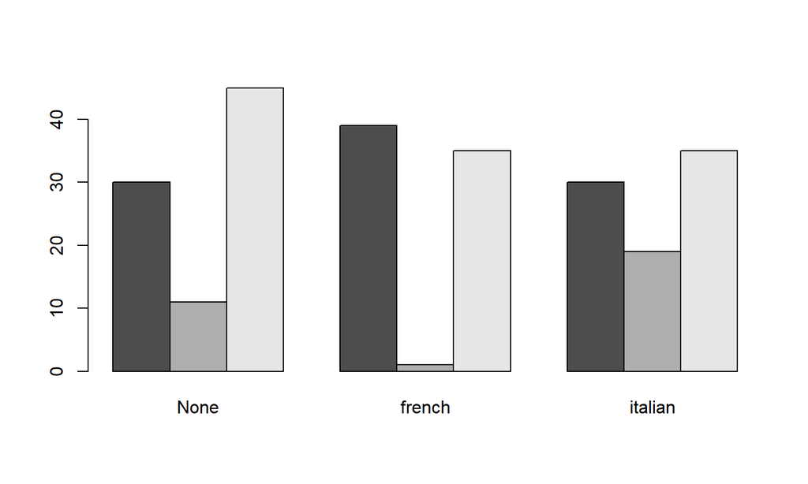

```r
barplot(music.wine, beside = T)
```

## Okay, a better barplot !

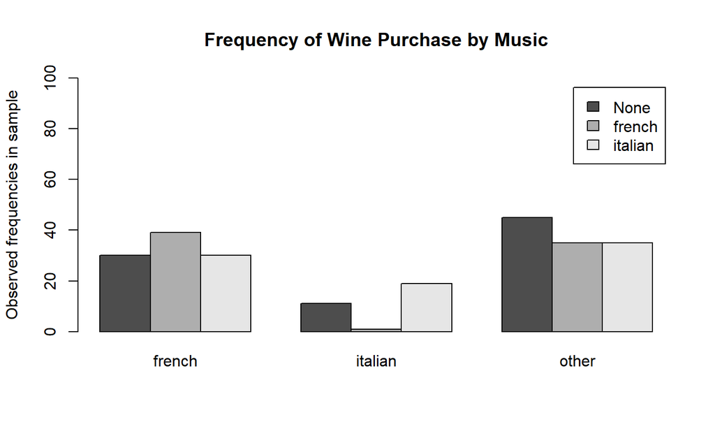

```r
barplot(t(music.wine), beside=T, legend=T, ylim=c(0,100),
        ylab="Observed frequencies in sample",
        main="Frequency of Wine Purchase by Music")
```

## The Chi-square test

```r
chisq.test(music.wine)
```

```
##
##  Pearson's Chi-squared test
##
## data:  music.wine
## X-squared = 18.822, df = 4, p-value = 0.0008519
```

## Pet ownership

```r
row1 = c(28,50)
row2 = c(11,3)
pet = rbind(row1,row2)
dimnames(pet) = list(survival = c("alive","dead"),
                            petownership=c("No","Yes"))
addmargins(pet)
```

```
##         petownership
## survival No Yes Sum
##    alive 28  50  78
##    dead  11   3  14
##    Sum   39  53  92
```

```r
prop.table(pet)
```

```
##         petownership
## survival        No       Yes
##    alive 0.3043478 0.5434783
##    dead  0.1195652 0.0326087
```

## Chi-square test

```r
chisq.test(pet)
```

```
##
##  Pearson's Chi-squared test with Yates' continuity correction
##
## data:  pet
## X-squared = 7.1899, df = 1, p-value = 0.007331
```

**R applies the Yates’ continuity correction automatically for 2x2 table. We can set it off, but we shouldn’t.**

```r
chisq.test(pet, correct = F)
```

```
##
##  Pearson's Chi-squared test
##
## data:  pet
## X-squared = 8.8511, df = 1, p-value = 0.002929
```

## Conclusion and validity

- We have enough evidence to say that there is an association between pet ownership and patient status in the population.
- It is appropriate to use the chi-square test because none of the cells have expected counts < 5.

```r
chisq.test(pet)$expected
```

```
##         petownership
## survival        No       Yes
##    alive 33.065217 44.934783
##    dead   5.934783  8.065217
```

## A Third Example

The following data are from a Stanford University study of the effectiveness of the antidepressant Celexa in the treatment of compulsive shopping. These data were found in Verzani (2005, p.262f), and the analysis here is similar to his.

```
                 outcome
             -----------------
   treat     worse same better
   ---------------------------
   Celexa      2     3     7
   placebo     2     8     2
   ---------------------------
```

## Data in R

```r
freqs = c(2, 2, 3, 8, 7, 2) # entered "down the columns"
shopping = matrix(freqs, nrow=2) #fills down columns by default
dimnames(shopping) = list(treatment=c("Celexa","placebo"),
                             outcome=c("worse","same","better"))
addmargins(prop.table(shopping))
```

```
##          outcome
## treatment      worse      same     better Sum
##   Celexa  0.08333333 0.1250000 0.29166667 0.5
##   placebo 0.08333333 0.3333333 0.08333333 0.5
##   Sum     0.16666667 0.4583333 0.37500000 1.0
```

## Chi-square test and its validity

```r
chisq.test(shopping)
```

```
## Warning in chisq.test(shopping): Chi-squared approximation may be incorrect
```

```
##
##  Pearson's Chi-squared test
##
## data:  shopping
## X-squared = 5.0505, df = 2, p-value = 0.08004
```

## Small counts

```r
chisq.test(shopping)$expected
```

```
## Warning in chisq.test(shopping): Chi-squared approximation may be incorrect
```

```
##          outcome
## treatment worse same better
##   Celexa      2  5.5    4.5
##   placebo     2  5.5    4.5
```

- The P-value might not be accurate.
- Options 1: p-value calculated by Monte Carlo simulation.

## Monte Carlo

- Simulate the sampling distribution of the test statistic (in this case, chi squared) using Monte Carlo methods.

```r
chisq.test(shopping, simulate.p.value=T)
```

```
##
##  Pearson's Chi-squared test with simulated p-value (based on 2000
##  replicates)
##
## data:  shopping
## X-squared = 5.0505, df = NA, p-value = 0.1009
```

- Another option is Fisher’s exact test, that works for a 2x2 table.
- In class, we will learn Fisher’s exact test for 2x2 tables !
- The R function can do FET for larger than 2x2 tables, but the accuracy is a concern for large expected frequencies.

## Fisher’s exact test

```r
fisher.test(shopping)
```

```
##
##  Fisher's Exact Test for Count Data
##
## data:  shopping
## p-value = 0.07303
## alternative hypothesis: two.sided
```

- Still a large P-value !
- We should retain the null hypothesis, and “it doesn’t look like we can fish up a signficant relationship here!”

## Another Example

```
##               nicotine
## alcohol        None 1-15 16 or more
##   none          105    7         11
##   0.01-0.1       58    5         13
##   0.11-0.99      84   37         42
##   1.00 or more   37   16         17
```

## Another Example (contd.)

```r
chisq.test(alcohol, correct = F)
```

```
##
##  Pearson's Chi-squared test
##
## data:  alcohol
## X-squared = 46.74, df = 6, p-value = 2.109e-08
```

None of the cells have expected counts < 5.

```r
chisq.test(alcohol)$expected
```

```
##               nicotine
## alcohol             None     1-15 16 or more
##   none          80.86111 18.50694   23.63194
##   0.01-0.1      49.96296 11.43519   14.60185
##   0.11-0.99    107.15741 24.52546   31.31713
##   1.00 or more  46.01852 10.53241   13.44907
```

## Association Measures

In R, use the package “vcd”, function assocstats()

In case of a 2-dimensional table, a list with components:

| chisq_tests | a 2 x 3 table with the chi-squared statistics |
| --- | --- |
| phi | The absolute value of the phi coefficient (only defined for 2 x 2 tables) |
| cont | The contingency coefficient |
| cramer | Cramer’s V |

## Association Measures ~ Music & Wine

```r
#install.packages("vcd")
library(vcd)
assocstats(music.wine)
```

```
##                     X^2 df   P(> X^2)
## Likelihood Ratio 22.285  4 0.00017585
## Pearson          18.822  4 0.00085186
##
## Phi-Coefficient   : NA
## Contingency Coeff.: 0.267
## Cramer's V        : 0.196
```

## Association Measures ~ Pet Ownership

```r
#install.packages("vcd")
library(vcd)
assocstats(pet)
```

```
##                     X^2 df  P(> X^2)
## Likelihood Ratio 9.0113  1 0.0026832
## Pearson          8.8511  1 0.0029291
##
## Phi-Coefficient   : 0.31
## Contingency Coeff.: 0.296
## Cramer's V        : 0.31
```

R gives us \(\phi\) because it is a 2x2 table.

## Association Measures ~ Shopping

```r
#install.packages("vcd")
library(vcd)
assocstats(shopping)
```

```
##                     X^2 df P(> X^2)
## Likelihood Ratio 5.3002  2 0.070644
## Pearson          5.0505  2 0.080038
##
## Phi-Coefficient   : NA
## Contingency Coeff.: 0.417
## Cramer's V        : 0.459
```

## Association Measures

```r
#install.packages("vcd")
library(vcd)
assocstats(alcohol)
```

```
##                     X^2 df   P(> X^2)
## Likelihood Ratio 49.816  6 5.1184e-09
## Pearson          46.740  6 2.1088e-08
##
## Phi-Coefficient   : NA
## Contingency Coeff.: 0.312
## Cramer's V        : 0.233
```

## Lady tasting tea

```r
tea<- matrix(c(3, 1, 1, 3), ncol= 2,
             dimnames = list(Truth = c("Tea","Milk" ),
                        Lady_says = c("Tea first","Milk first")))
tea
```

```
##       Lady_says
## Truth  Tea first Milk first
##   Tea          3          1
##   Milk         1          3
```

## Lady tasting tea : Fisher’s Exact Test

```r
fisher.test(tea)
```

```
##
##  Fisher's Exact Test for Count Data
##
## data:  tea
## p-value = 0.4857
## alternative hypothesis: true odds ratio is not equal to 1
## 95 percent confidence interval:
##    0.2117329 621.9337505
## sample estimates:
## odds ratio
##   6.408309
```

## One-sided test

- Fisher’s exact test can be one-sided or two-sided, based on the Odds ratio, which measures association for a 2x2 table, high odds ratio means higehr association.

```r
fisher.test(tea, alternative = "greater")
```

```
##
##  Fisher's Exact Test for Count Data
##
## data:  tea
## p-value = 0.2429
## alternative hypothesis: true odds ratio is greater than 1
## 95 percent confidence interval:
##  0.3135693       Inf
## sample estimates:
## odds ratio
##   6.408309
```

## More examples

The data in table 1 come from an RCT comparing intramuscular magnesium injections with placebo for the treatment of chronic fatigue syndrome Of the 15 patients who had the intra-muscular magnesium injections 12 felt better (80 per cent) whereas, of the 17 on placebo, only three felt better (18 per cent).

|  | Magnesium | Placebo |
| --- | --- | --- |
| Felt Better | 12 | 3 |
| Fel worse | 3 | 14 |

## Using R

```r
RCT <- matrix(c(12,3,3,14), ncol= 2,
             dimnames = list(Outcome = c("Better", "Worse" ),
                        Medicine = c("Magnesium", "Placebo")))

chisq.test(RCT)
```

```
##
##  Pearson's Chi-squared test with Yates' continuity correction
##
## data:  RCT
## X-squared = 10.063, df = 1, p-value = 0.001512
```

## Validity

```r
chisq.test(RCT)$expected
```

```
##         Medicine
## Outcome  Magnesium Placebo
##   Better   7.03125 7.96875
##   Worse    7.96875 9.03125
```

The expected counts are all more than 5 so a chi-sqaure approximation would be valid here, but, we can still do Fisher’s exact test to get the exact P-value.

```r
fisher.test(RCT)
```

```
##
##  Fisher's Exact Test for Count Data
##
## data:  RCT
## p-value = 0.001033
## alternative hypothesis: true odds ratio is not equal to 1
## 95 percent confidence interval:
##    2.507119 159.407427
## sample estimates:
## odds ratio
##   16.41917
```

## Statistical and Practical Significance

- Statistical significance depends on sample size.
- Data on french skiers who took either Vitamin C or placebo, and either got a cold or not.

```r
cold <- matrix(c(31,109,17,122), ncol= 2,
             dimnames = list(Outcome = c("Placebo", "Ascorbic Acid" ),
                        Medicine = c("Cold", "No Cold")))
cold
```

```
##                Medicine
## Outcome         Cold No Cold
##   Placebo         31      17
##   Ascorbic Acid  109     122
```

## Statistical and Practical Significance

- Statistical significance depends on sample size.

```r
cold <- matrix(c(31,109,17,122), ncol= 2,
             dimnames = list(Outcome = c("Placebo", "Ascorbic Acid" ),
                        Medicine = c("Cold", "No Cold")))
chisq.test(cold)
```

```
##
##  Pearson's Chi-squared test with Yates' continuity correction
##
## data:  cold
## X-squared = 4.1407, df = 1, p-value = 0.04186
```

## Statistical and Practical Significance

- Statistical significance depends on sample size.
- Now we multiply each cell by 10.

```r
cold <- matrix(c(310,1090,170,1220), ncol= 2,
             dimnames = list(Outcome = c("Placebo", "Ascorbic Acid" ),
                        Medicine = c("Cold", "No Cold")))
chisq.test(cold)
```

```
##
##  Pearson's Chi-squared test with Yates' continuity correction
##
## data:  cold
## X-squared = 47.421, df = 1, p-value = 5.727e-12
```

- VERY strong evidence against null - not because association has increased, but sample size is higher.

## Statistical and Practical Significance

- Statistical significance depends on sample size.
- Now we divide each cell by 10, and round up.

```r
cold <- matrix(c(3,11, 2,12), ncol= 2,
             dimnames = list(Outcome = c("Placebo", "Ascorbic Acid" ),
                        Medicine = c("Cold", "No Cold")))
chisq.test(cold)
```

```
##
##  Pearson's Chi-squared test with Yates' continuity correction
##
## data:  cold
## X-squared = 0, df = 1, p-value = 1
```

- little or no evidence against independence, but is it because weak association or low sample size?

## Odds ratio

- Most common measure of association for a 2x2 table.
- Odds are The odds are ratios of probabilities of “success” and “failure” for a given row, or a ratio of conditional probabilities of the same conditional distribution.
- Last example, odds of getting a cold versus not getting a cold, given he took placebo: \[ odds_1 = \frac{P( Z = cold | Y = placebo)}{P(Z = no cold | Y = placebo)} \]
- odds of getting a cold versus not getting a cold, given he took Vit-C: \[ odds_2 = \frac{P( Z = cold | Y = Vit-C)}{P(Z = no cold | Y = Vit-C)} \]

## Odds ratio

- If odds equal to 1, “success” and “failure” are equally likely.
- If odds > 1, then “success” is more likely than “failure”.
- If odds < 1, then “success” is less likely than “failure”.
- Let “C” = cold, “NC” = no cold, “Pl” = Placebo, “VitC” = Vitamin C.

The odds ratio, is the ratio of odds1 and odds2: \[ OR = \frac{P( Z = C | Y = Pl) \times P(Z = NC | Y = VitC)}{P(Z = NC | Y = Pl)\times P( Z = C | Y = VitC)} \]

## Calculation

- Generalize: 2x2 table with two variables Y and Z, both binary.

|  | Z = 1 |  | Z = 2 |
| --- | --- | --- | --- |
| Y = 1 | \(n_{11}\),\(\pi_{11}\) \| \(n_{12}\),\(\pi_{12}\) |  |  |
| Y = 2 | \(n_{12}\),\(\pi_{12}\) \| \(n_{22}\),\(\pi_{22}\) |  |  |

\[ \theta = \mbox{Odds ratio} = \frac{\pi_{11}\pi_{22}}{\pi_{12}\pi_{21}} \] Natural estimate: \[ \hat{\theta} = \mbox{Estimated Odds ratio} = \frac{n_{11}n_{22}}{n_{12}n_{21}} \]

## Interpretation:

- Independence: \(\theta = 1\)
- Dependence: \(\pi_{1|1} > \pi_{1|2}\) implies \(\theta > 1\). Odds of success in row 1 is higher than odds of success in row 2.
- Or, \(\pi_{1|1} < \pi_{1|2}\) implies \(\theta < 1\). Odds of success in row 1 is lower than odds of success in row 2.

## Odds ratio

- The odds ratio depends on the cell probabilities that doesn’t change with sample size.

```r
cold <- matrix(c(31,109,17,122), ncol= 2,
             dimnames = list(Outcome = c("Placebo", "Ascorbic Acid" ),
                        Medicine = c("Cold", "No Cold")))
OR = cold[1,1]*cold[2,2]/(cold[1,2]*cold[2,1]); cat(OR)
```

```
## 2.041015
```

```r
cold <- matrix(c(310,1090,170,1220), ncol= 2,
             dimnames = list(Outcome = c("Placebo", "Ascorbic Acid" ),
                        Medicine = c("Cold", "No Cold")))
OR = cold[1,1]*cold[2,2]/(cold[1,2]*cold[2,1]); cat(OR)
```

```
## 2.041015
```

## Interpretation

```
##                Medicine
## Outcome         Cold No Cold
##   Placebo         31      17
##   Ascorbic Acid  109     122
```

```r
OR = cold[1,1]*cold[2,2]/(cold[1,2]*cold[2,1]); cat("Odds ratio", OR)
```

```
## Odds ratio 2.041015
```

For our example, \(OR = 2.04\) means that:

1. the odds of getting a cold given a placebo are 2.04 times greater than the odds of given vitamin C.
2. the odds of getting a cold given vitamin C are 1/2.04 = 0.49 times the odds of getting cold given a placebo.
3. getting cold is less likely given vitamin C than given a placebo.

## McNemar’s test

```r
sales.data <- matrix(c(5, 13, 4, 6), ncol= 2,
             dimnames = list(Before = c("Acceptable","Unacceptable" ),
                         After = c("Acceptable","Unacceptable" )))
sales.data
```

```
##               After
## Before         Acceptable Unacceptable
##   Acceptable            5            4
##   Unacceptable         13            6
```

```r
mcnemar.test(sales.data , correct = FALSE)
```

```
##
##  McNemar's Chi-squared test
##
## data:  sales.data
## McNemar's chi-squared = 4.7647, df = 1, p-value = 0.02905
```

## Exact McNemar’s test

```r
# install.packages("exact2x2")
library(exact2x2)
mcnemar.exact(sales.data)
```

```
##
##  Exact McNemar test (with central confidence intervals)
##
## data:  sales.data
## b = 4, c = 13, p-value = 0.04904
## alternative hypothesis: true odds ratio is not equal to 1
## 95 percent confidence interval:
##  0.07308542 0.99598118
## sample estimates:
## odds ratio
##  0.3076923
```